# Exploring Ford GoBike Trip Data

## by: Hadeer Ismail

## Investigation Overview

> Our Investigation is concerned with comparing Different criteria with trip duration. Our interest is in the relationship between user_type, gender, age and trip duration.

## Dataset Overview

> Ford GoBike dataset include 183412 record for trips data covering San Francisco Bay area. with 16 Features like start and end station, trip duration, bike identifier and user data like user type, gender and birthyear. We added Column for Age. After cleaning data we ended with 174708 row and 17 column.

## 1. Gender and Subscription proportions

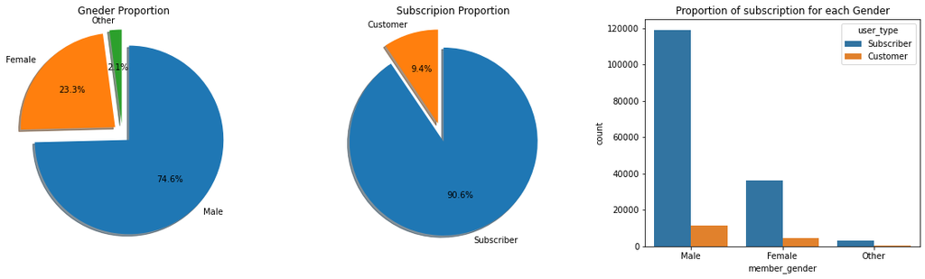

```python
plt.figure(figsize=[20,5])
plt.subplot(1,3,1)
#Create pie chart for users gender
gender_count = bike_df.member_gender.value_counts()
plt.pie(gender_count, labels=gender_count.index,startangle=90, counterclock=False, autopct='%1.1f%%',shadow=True,explode=(0.1, 0.1, 0.1) )
#Apply scaling to the plot to be equal on both the x- and y-axes.
plt.axis('square')
plt.title('Gneder Proportion')

plt.subplot(1,3,2)
#Create pie chart for users type
user_type_count = bike_df.user_type.value_counts()
plt.pie(user_type_count, labels=user_type_count.index,startangle=90, counterclock=False, autopct='%1.1f%%',shadow=True,explode=(0.1, 0.1) )
#Apply scaling to the plot to be equal on both the x- and y-axes.
plt.axis('square')
plt.title('Subscripion Proportion')

#Bar plot shows relation between gender and subscribtion
plt.subplot(1,3,3)
sb.countplot(data = bike_df, x = 'member_gender', hue = 'user_type')
plt.title('Proportion of subscription for each Gender')
```

## 2. Duration, Birthyear and User type.

- Customer trip duration in almost all birthyears was greater than subscribers trip duration

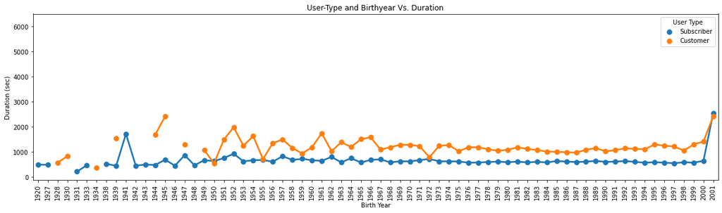

```python
#Point plot shows the average trip duration for every birthyear from different user types
plt.figure(figsize=[20,5])
sb.pointplot(data=bike_df, x='member_birth_year', y='duration_sec',hue='user_type', errwidth=0)
plt.xticks(rotation=90)
plt.title('User-Type and Birthyear Vs. Duration')
plt.xlabel('Birth Year')
plt.ylabel('Duration (sec)')
plt.legend(loc='upper right', title='User Type')
```

## 3. Gender and Birthyear Vs. Trip Duration

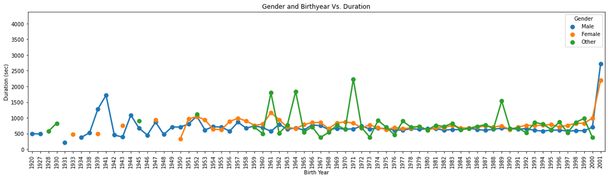

```python
#Point plot shows the average trip duration for every birthyear with different gender
plt.figure(figsize=[20,5])
sb.pointplot(data=bike_df, x='member_birth_year', y='duration_sec',hue='member_gender', errwidth=0)
plt.xticks(rotation=90)
plt.title('Gender and Birthyear Vs. Duration')
plt.xlabel('Birth Year')
plt.ylabel('Duration (sec)')
plt.legend(loc='upper right',title='Gender')
```

## Conclusion

- Number of male users are the largest among the rest gender.
- Number of Subscription above 90%.
- Customers have Higher trip duration than subscribers.

## point of view

- Marketing team can focus on attracting Female users.